# R Notebook

```r
library(tidyverse)
```

```r
summary <- read_rds("summarySCC_PM25.rds") %>%as_tibble(rownames = "tons") %>% mutate(tons=as.numeric(tons))
summary
```

| tons | fips | SCC | Pollutant | Emissions | type | year |
| --- | --- | --- | --- | --- | --- | --- |
| 4 | 09001 | 10100401 | PM25-PRI | 15.714 | POINT | 1999 |
| 8 | 09001 | 10100404 | PM25-PRI | 234.178 | POINT | 1999 |
| 12 | 09001 | 10100501 | PM25-PRI | 0.128 | POINT | 1999 |
| 16 | 09001 | 10200401 | PM25-PRI | 2.036 | POINT | 1999 |
| 20 | 09001 | 10200504 | PM25-PRI | 0.388 | POINT | 1999 |
| 24 | 09001 | 10200602 | PM25-PRI | 1.490 | POINT | 1999 |
| 28 | 09001 | 10200603 | PM25-PRI | 0.200 | POINT | 1999 |
| 32 | 09001 | 10300401 | PM25-PRI | 0.081 | POINT | 1999 |
| 36 | 09001 | 10300501 | PM25-PRI | 0.184 | POINT | 1999 |
| 40 | 09001 | 10300504 | PM25-PRI | 0.273 | POINT | 1999 |

[output cut: 990 more lines]

```r
source_classification <- read_rds("Source_Classification_Code.rds") %>% as_tibble()
source_classification
```

| SCC | Data.Category | Short.Name | EI.Sector | Option.Group | Option.Set | SCC.Level.One | SCC.Level.Two | SCC.Level.Three | SCC.Level.Four | Map.To | Last.Inventory.Year | Created_Date | Revised_Date | Usage.Notes |
| --- | --- | --- | --- | --- | --- | --- | --- | --- | --- | --- | --- | --- | --- | --- |
| 10100101 | Point | Ext Comb /Electric Gen /Anthracite Coal /Pulverized Coal | Fuel Comb - Electric Generation - Coal |  |  | External Combustion Boilers | Electric Generation | Anthracite Coal | Pulverized Coal | NA | NA |  |  |  |
| 10100102 | Point | Ext Comb /Electric Gen /Anthracite Coal /Traveling Grate (Overfeed) Stoker | Fuel Comb - Electric Generation - Coal |  |  | External Combustion Boilers | Electric Generation | Anthracite Coal | Traveling Grate (Overfeed) Stoker | NA | NA |  |  |  |
| 10100201 | Point | Ext Comb /Electric Gen /Bituminous Coal /Pulverized Coal: Wet Bottom | Fuel Comb - Electric Generation - Coal |  |  | External Combustion Boilers | Electric Generation | Bituminous/Subbituminous Coal | Pulverized Coal: Wet Bottom (Bituminous Coal) | NA | NA |  |  |  |
| 10100202 | Point | Ext Comb /Electric Gen /Bituminous Coal /Pulverized Coal: Dry Bottom | Fuel Comb - Electric Generation - Coal |  |  | External Combustion Boilers | Electric Generation | Bituminous/Subbituminous Coal | Pulverized Coal: Dry Bottom (Bituminous Coal) | NA | NA |  |  |  |
| 10100203 | Point | Ext Comb /Electric Gen /Bituminous Coal /Cyclone Furnace | Fuel Comb - Electric Generation - Coal |  |  | External Combustion Boilers | Electric Generation | Bituminous/Subbituminous Coal | Cyclone Furnace (Bituminous Coal) | NA | NA |  |  |  |
| 10100204 | Point | Ext Comb /Electric Gen /Bituminous Coal /Spreader Stoker | Fuel Comb - Electric Generation - Coal |  |  | External Combustion Boilers | Electric Generation | Bituminous/Subbituminous Coal | Spreader Stoker (Bituminous Coal) | NA | NA |  |  |  |
| 10100205 | Point | Ext Comb /Electric Gen /Bituminous Coal /Traveling Grate (Overfeed) Stoker | Fuel Comb - Electric Generation - Coal |  |  | External Combustion Boilers | Electric Generation | Bituminous/Subbituminous Coal | Traveling Grate (Overfeed) Stoker (Bituminous Coal) | NA | NA |  |  |  |
| 10100211 | Point | Ext Comb /Electric Gen /Bituminous Coal /Wet Bottom (Tangential) | Fuel Comb - Electric Generation - Coal |  |  | External Combustion Boilers | Electric Generation | Bituminous/Subbituminous Coal | Wet Bottom (Tangential) (Bituminous Coal) | NA | NA |  |  |  |
| 10100212 | Point | Ext Comb /Electric Gen /Bituminous Coal /Pulverized Coal: Dry Bottom (Tangential) | Fuel Comb - Electric Generation - Coal |  |  | External Combustion Boilers | Electric Generation | Bituminous/Subbituminous Coal | Pulverized Coal: Dry Bottom (Tangential) (Bituminous Coal) | NA | NA |  |  |  |
| 10100215 | Point | Ext Comb /Electric Gen /Bituminous Coal /Cell Burner | Fuel Comb - Electric Generation - Coal |  |  | External Combustion Boilers | Electric Generation | Bituminous/Subbituminous Coal | Cell Burner (Bituminous Coal) | NA | NA |  |  |  |

[output cut: 990 more lines]

```r
summary$year %>% unique()
```

```
[1] 1999 2002 2005 2008
```

#Have total emissions from PM2.5 decreased in the United States from 1999 to 2008? Using the base plotting system, make a plot showing the total PM2.5 emission from all sources for each of the years 1999, 2002, 2005, and 2008.

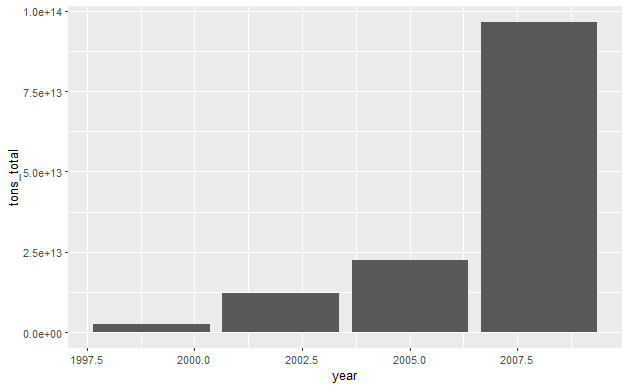

```r
p1 <- summary %>% group_by(year) %>% summarise(tons_total=sum(tons)) %>% ggplot(aes(year,tons_total))+geom_col()


ggsave("plot1.png", plot = p1)
p1
```

## Theres an increase over the years

#Have total emissions from PM2.5 decreased in the Baltimore City, Maryland (fips == “24510”) from 1999 to 2008? Use the base plotting system to make a plot answering this question.

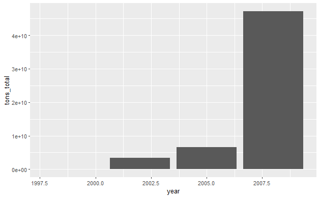

```r
p2 <- summary %>% filter(fips=="24510") %>% group_by(year) %>% summarise(tons_total=sum(tons)) %>% ggplot(aes(year,tons_total))+geom_col()
p2
```

##yes emmisions have also increased in Baltimore # #

#Of the four types of sources indicated by the (point, nonpoint, onroad, nonroad) variable, which of these four sources have seen decreases in emissions from 1999–2008 for Baltimore City? Which have seen increases in emissions from 1999–2008? Use the ggplot2 plotting system to make a plot answer this question.

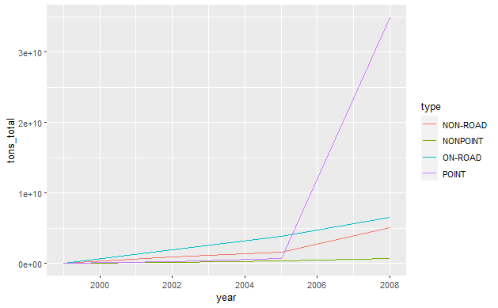

```r
p3 <- summary%>% filter(fips=="24510") %>% group_by(year, type) %>% summarise(tons_total=sum(tons)) %>% ggplot(aes(year,tons_total, color=type))+geom_line()
p3
```

## Answer 2) all have incresed

#Across the United States, how have emissions from coal combustion-related sources changed from 1999–2008?

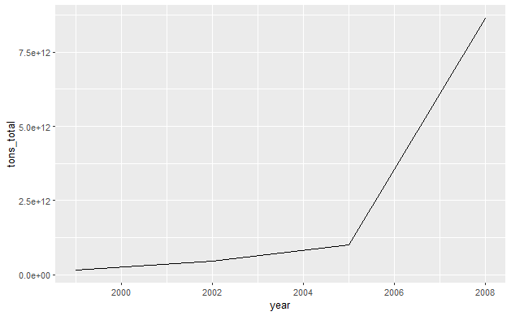

```r
left_join(comb,summary)%>% group_by(year) %>% summarise(tons_total=sum(tons)) %>% ggplot(aes(year,tons_total))+geom_line()
```

##emissions from coal combustion-related sources have risen

#How have emissions from motor vehicle sources changed from 1999–2008 in Baltimore City?

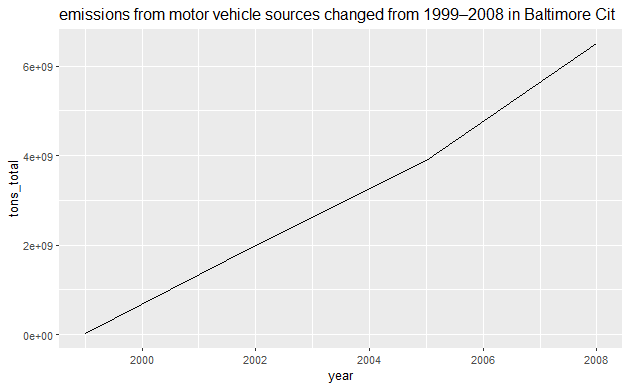

```r
source_classification %>% left_join(summary)%>%
  group_by(year) %>%
  filter(EI.Sector %in% str_subset(EI.Sector,fixed('vehicle', ignore_case=TRUE))) %>%
  filter(fips=="24510") %>%
  summarise(tons_total=sum(tons)) %>% ggplot(aes(year,tons_total))+geom_line() + ggtitle("emissions from motor vehicle sources changed from 1999–2008 in Baltimore Cit")
```

##they have quita dramtically risen

#Compare emissions from motor vehicle sources in Baltimore City with emissions from motor vehicle sources in Los Angeles County, California (fips == “06037”). Which city has seen greater changes over time in motor vehicle emissions?

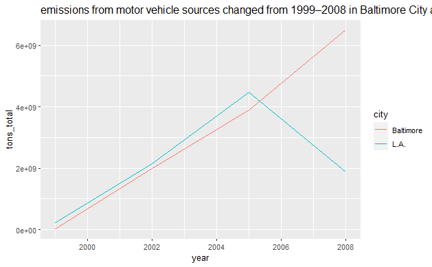

```r
source_classification %>% left_join(summary)%>%
  filter(EI.Sector %in% str_subset(EI.Sector,fixed('vehicle', ignore_case=TRUE))) %>%
  filter(fips%in% c("24510","06037")) %>% mutate(city=ifelse(fips=="24510","Baltimore","L.A.")) %>%  group_by(year,city) %>%
  summarise(tons_total=sum(tons)) %>% ggplot(aes(year,tons_total, color=city))+geom_line() + ggtitle("emissions from motor vehicle sources changed from 1999–2008 in Baltimore City and LA")
```

#LA could reduce its emissions in the last years